# AdvRegHW_9

Nashrah Ahmed

February 18, 2018

## Exercise 5, Chapter 8

1. Consider the economy and voting example from Section 7.2. Fit the linear regression model to the data through 2012 which are available at ElectionsEconomy. Make a forcast for the incumbent party’s share of the two-party vote in a future election where economic growth is 2%.(a) Compute the point forcast, the standard deviation of the linear predictor from 8.3, and the standard deviation of the predicted value from 8.4.

```r
setwd("/Users/Nashrah/Desktop/Columbia_QMSS/Spring 2018 Courses/Advanced Regression Modeling")

hibbs <- read.table("hibbs.dat", header = TRUE)

P_Forcast <- stan_glm(inc.party.vote ~ growth, data=hibbs)
```

[output not shown]

[output cut: 40 more lines]

[output not shown]

```r
print(P_Forcast)
```

```
## stan_glm
##  family:       gaussian [identity]
##  formula:      inc.party.vote ~ growth
##  observations: 16
##  predictors:   2
## ------
##             Median MAD_SD
## (Intercept) 46.3    1.7
## growth       3.0    0.7
## sigma        3.9    0.7
##
## Sample avg. posterior predictive distribution of y:
##          Median MAD_SD
## mean_PPD 52.0    1.3
##
## ------
## For info on the priors used see help('prior_summary.stanreg').
```

```r
#linear predictor = a + bx
#predicted value = a + bx + error
#median-based estimates and standard errors: when using simulation draws, our point estimate of any parameter will be its median, and standard error will be median-based calc * 1.483
```

```r
sims <- as.matrix(P_Forcast)
n_sims <- nrow(sims)
a <- sims[,1]
b <- sims[,2]
sigma <- sims[,3]

p_estimate <- median(a)
p_estimate
```

```
## [1] 46.26198
```

```r
std_error <- 1.483*median(abs(a-median(a)))
std_error
```

```
## [1] 1.705399
```

```r
new_hibbs <- data.frame(growth=2.0)

y_pred1 <- posterior_predict(P_Forcast, newdata=new_hibbs)
median1 <- median(y_pred1)
median1
```

```
## [1] 52.34161
```

```r
std_error1 <- mad(y_pred1)
std_error1
```

```
## [1] 3.879708
```

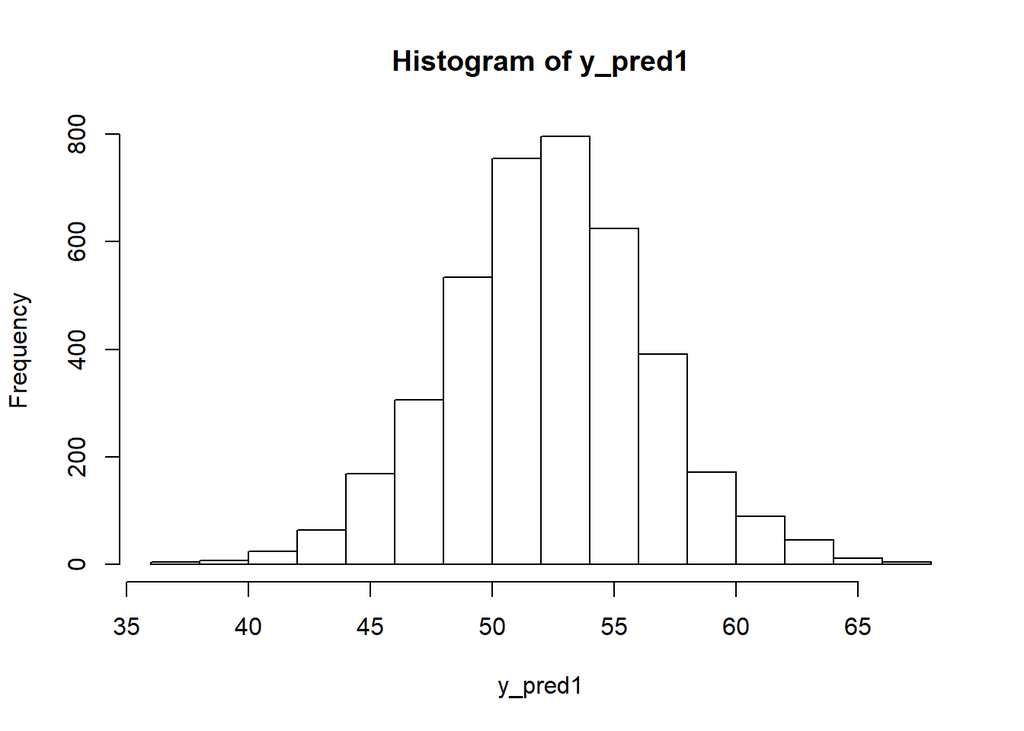

```r
hist(y_pred1)
```

```r
x <- rnorm(n_sims, 2.0)
y_hat <- a + b*x
y_pred <- rnorm(n_sims, y_hat, sigma)
Median <- median(y_pred)
P_SD2 <- mad(y_pred)
win_prob <- mean(y_pred > 50)
cat("Predicted Incumbent's Party's Share of 2-Party Vote: ", fround(Median,1), ", with s.e. ", fround(P_SD2, 1), "\nPr (hibbs) = ", fround(win_prob, 2), sep="")
```

```
## Predicted Incumbent's Party's Share of 2-Party Vote: 52.2, with s.e. 5.0
## Pr (hibbs) = 0.67
```

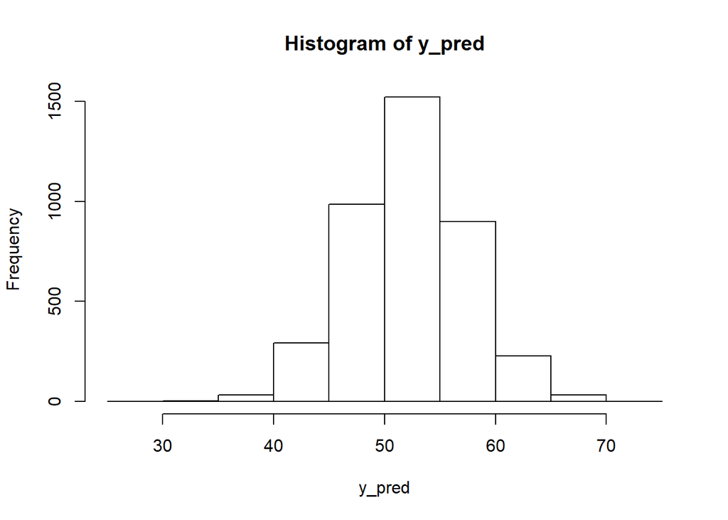

```r
hist(y_pred)
```

```r
#Higher standard deviation for second method
```

## Exercise 6, Chapter 8

Uniform, weakly informative, and informative priors: Follow the steps of Section 8.5 for a different example, a regression of earnings on height using the data from the folder Earnings. You will need to think what could be an informative prior distribution in this setting.

```r
Earnings <- read.csv("Earnings.csv", header = TRUE)
#eliminate 0s for earn
Earnings2 <- data.frame(Earnings)
Earnings3 <- Earnings2[apply(Earnings2!=0, 1, all),]
#height in inches
avg <- round(mean(Earnings3$height), 2)
Earnings3$n_height <- Earnings3$height - avg
P_Forcast_n <- stan_glm(earn ~ n_height, data=Earnings3)
```

[output not shown]

[output cut: 40 more lines]

[output not shown]

```r
print(P_Forcast_n)
```

```
## stan_glm
##  family:       gaussian [identity]
##  formula:      earn ~ n_height
##  observations: 423
##  predictors:   2
## ------
##             Median  MAD_SD
## (Intercept) 29294.5  1190.9
## n_height      759.1   375.4
## sigma       23297.1   778.2
##
## Sample avg. posterior predictive distribution of y:
##          Median  MAD_SD
## mean_PPD 29262.8  1609.3
##
## ------
## For info on the priors used see help('prior_summary.stanreg').
```

```r
sims_n <- as.matrix(P_Forcast_n)
n_sims2 <- nrow(sims_n)
a_n <- sims_n[,1]
b_n <- sims_n[,2]
sigma_n <- sims_n[,3]

p_estimate_n <- median(a_n)
p_estimate_n
```

```
## [1] 29294.49
```

```r
std_error_n <- 1.483*median(abs(a_n-median(a_n)))
std_error_n
```

```
## [1] 1191.196
```

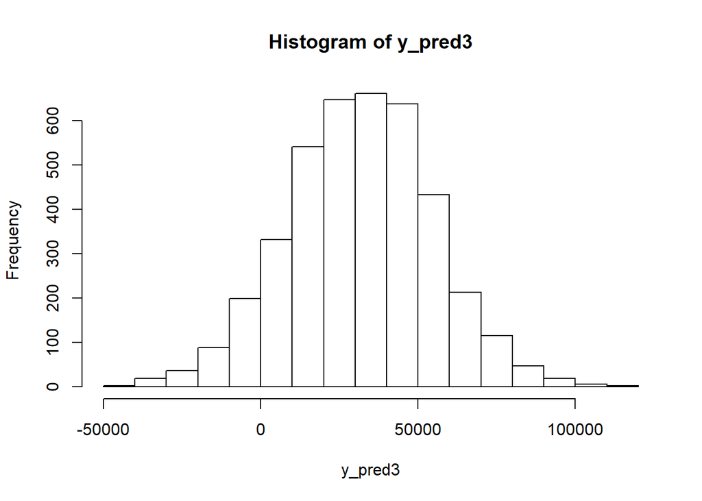

```r
#Used average height of man and woman in 2017: 66.75
n_avg <- avg - 66.75
new_Earnings <- data.frame(n_height=n_avg)

y_pred3 <- posterior_predict(P_Forcast_n, newdata=new_Earnings)
median3 <- median(y_pred3)
std_error3 <- mad(y_pred3)
hist(y_pred3)
```

```r
x1 <- rnorm(n_sims2, n_avg)
y_hat3 <- a + b*x1
y_pred4 <- rnorm(n_sims2, y_hat3, sigma_n)
Median4 <- median(y_pred4)
P_SD3 <- mad(y_pred4)
cat("Predicted Earnings: ", fround(Median4,1), ", with s.e. ", fround(P_SD3, 1), "\nPr (Earnings3) = ", sep="")
```

[output not shown]

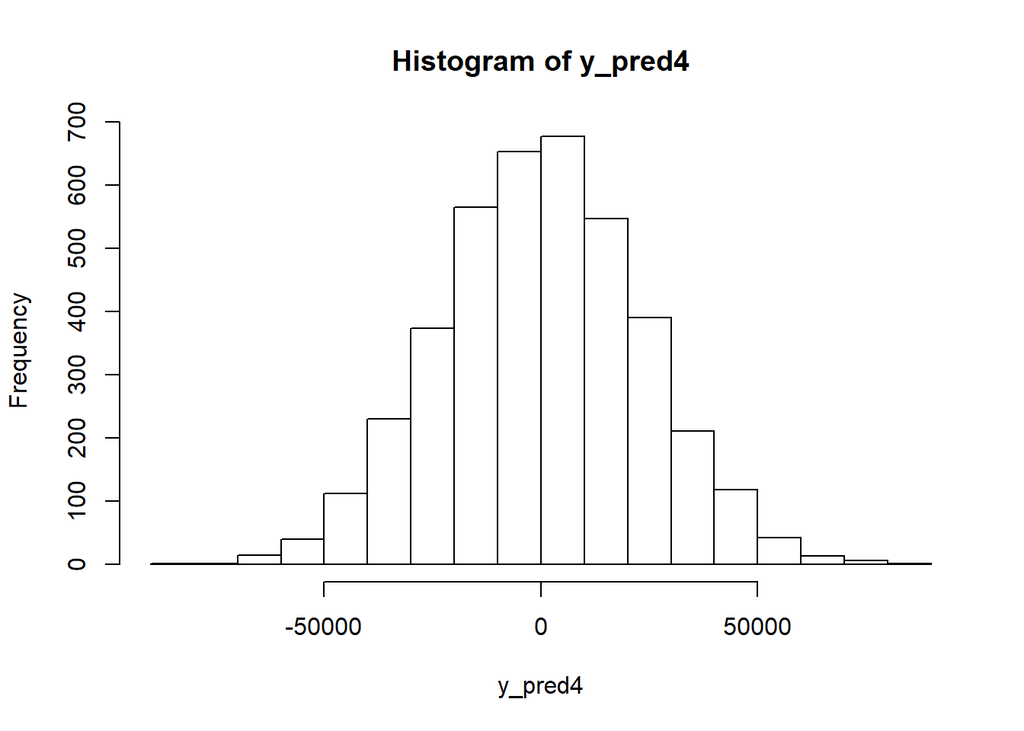

```r
hist(y_pred4)
```

```r
#lower standard deviation for second method
```

[output not shown]

## Exercise 7, Chapter 8

Decision analysis: An experiment is performed to measure the efficacy of a television advertising program. The result in an estimate that each minute spent on a national advertising program will increase sales by $500,000 and this estimate has a standard error of $200,000. Assume the uncertainty in the treatment effect can be approximated by a normal distribution. Suppose ads cost $300,000 per minute. What is the expected net gain for purchasing 20 mins of ads? What is the probability that the net gain is negative?

```r
cost <- 300000*20
cost
```

```
## [1] 6e+06
```

```r
a <- 0
b <- 500000
sigma <- 200000
x <- 20

y_hat_d <- a + b*x + rnorm(1, 0, sigma)
y_hat_d
```

```
## [1] 9525922
```

```r
est_net_gain <- y_hat_d - cost
est_net_gain
```

```
## [1] 3525922
```

```r
# I am not sure this is how you wanted us to answer this question
y_pred_d <- rnorm(n_sims, y_hat_d)

median_d <- median(y_pred_d)
mad_sd_d <- mad(y_pred_d)
netgain_prob <- mean(y_pred_d < 0)
cat("Pred Efficacy of Television Adv Program: ", fround(median_d,1), ", with s.e. ", fround(mad_sd_d, 1), "\nPr (net loss) = ", fround(netgain_prob, 2), sep="")
```

```
## Pred Efficacy of Television Adv Program: 9525921.6, with s.e. 1.0
## Pr (net loss) = 0.00
```

Shadow project: These exercises were helpful in comparing techniques for measuring uncertainty in the regression coefficients. Particularly the nuances between the linear predictor and the predicted value estimated by Bayesian methods.